# Bias in temperature-estimates on growth due to Rosa Lee effect

Author

Max Lindmark

Published

November 4, 2025

In this script, we extend the basic model (rosa-lee-basic-example.qmd) to include: temperature time series and temperature effects on growth.

```r
library(viridis)
library(ggdist)
library(patchwork)
library(viridis)
library(tidyverse)
library(ggsidekick)
library(purrr)
library(broom)
theme_set(theme_sleek())

# Set path
home <- here::here()
```

### Reload the basic parameters

```r
# Model parameters
set.seed(123)
n_years <- 100
n_ages <- 15
n_platoons <- 250  # Number of growth morphs/platoons
ages <- 0:(n_ages-1)

# Life history parameters
M <- 0.2           # Natural mortality
steep <- 0.7       # Steepness
R0 <- 1000         # Unfished recruitment (thousands)
mat_age <- 3       # Age at 50% maturity
mat_slope <- 0.5

# Selectivity parameters (logistic)
sel_age50 <- 4
sel_slope <- 0.8

# Growth parameters by platoon (von Bertalanffy)
# Each platoon has different VBGE pars
K_vals <- rnorm(n_platoons, mean = 0.3, sd = 0.1)

growth_params <- tibble(
  platoon = 1:n_platoons,
  Linf = 80,
  K = K_vals,
  t0 = -0.5,
  CV_old = 0.1,     # <! not used! Can use it for intra-platoon variability.
  prop = 1/n_platoons
)

# Length-weight parameters
a_lw <- 0.01
b_lw <- 3

# Calculate length and weight at age for each platoon
size_at_age <- growth_params |>
  crossing(age = ages) |>
  mutate(
    length = Linf * (1 - exp(-K * (age - t0))),
    weight = a_lw * length^b_lw
  ) |>
  select(platoon, age, Linf, K, t0, CV_old, length, weight)

# Maturity
maturity <- tibble(age = ages) |>
  mutate(
    maturity = plogis((age - mat_age) / mat_slope)
  )

# Selectivity needs to be size-based for Rosa Lee to occur:
L50_len <- 40   # length at 50% vulnerability (cm)
len_slope <- 1  # slope (larger => gentler logistic)

# Build length-based selectivity per platoon x age using size_at_age
selectivity <- size_at_age |>
  mutate(selectivity = plogis((length - L50_len) / len_slope)) |>
  select(platoon, age, length, selectivity)

# Get initial population values
init_pop <- crossing(
  year = 1,
  age = ages,
  platoon = 1:n_platoons
) |>
  left_join(growth_params |> select(platoon, prop), by = "platoon") |>
  mutate(
    # Unfished equilibrium age structure
    N = R0 * prop * exp(-M * age),
    N = if_else(age == max(age), N / (1 - exp(-M)), N)  # Plus group
  ) |>
  left_join(size_at_age, by = c("age", "platoon")) |>
  left_join(maturity, by = "age") |>
  left_join(selectivity |> select(platoon, age, selectivity),
            by = c("platoon", "age")) |>
  mutate(selectivity = ifelse(is.na(selectivity), 0, selectivity))

# Calculate unfished SSB (needed for S-R)
SSB0 <- init_pop |>
  mutate(SSB_contrib = N * weight * maturity) |>
  summarise(SSB0 = sum(SSB_contrib)) |>
  pull(SSB0)

# Beverton-Holt stock-recruitment function
# ss3 style! https://nmfs-ost.github.io/ss3-doc/SS330_User_Manual_release.html#BH
beverton_holt <- function(SSB, R0, steep, SSB0) {
  4 * steep * R0 * SSB / (SSB0 * (1 - steep) + SSB * (5 * steep - 1))
}

# Fishing mortality pattern (ramp up then stabilize)
F_longterm <- 0.4
F_pattern <- tibble(year = 1:n_years) |>
  mutate(
    F_mult = case_when(
      year <= 5 ~ 0,
      year <= 15 ~ (year - 5) / 10 * F_longterm,
      TRUE ~ F_longterm
    )
  )

# Also define the no-fishing scenario
F_pattern_unfished <- tibble(year = 1:n_years, F_mult = 0)
```

### Update the basic model to handle temperature and temperature effects on $K$

First, we need a temperature time series.

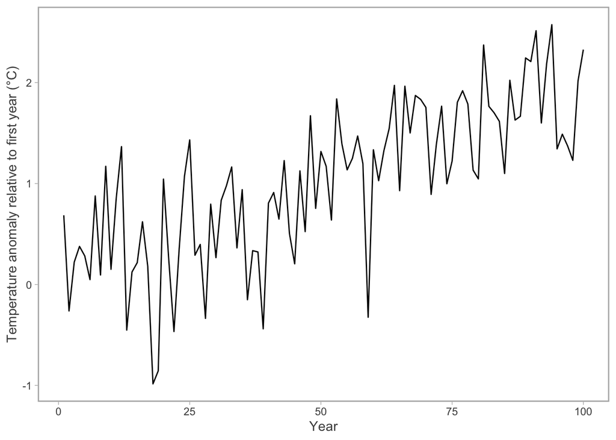

```r
# Build a warming series with noise. For simplicity, it's expressed as an anomaly.
# The function takes length of time series, what the total warming should be, and the level of noise
make_warming_series <- function(n_years, total_warming = 2, noise_sd = 0.5, seed = 42) {
  set.seed(seed)
  trend <- seq(0, total_warming, length.out = n_years)
  eps <- rnorm(n_years, 0, noise_sd)
  temp <- trend + eps
  tibble(year = 1:n_years, temp = temp)
}

# Example: 2°C over n_years
temp_series <- make_warming_series(n_years = n_years)
# Plot temperature anomaly
ggplot(temp_series, aes(year, temp)) + geom_line() +
  labs(y = "Temperature anomaly relative to first year (°C)", x = "Year")
```

```r
# Also define a no-warming scenario
temp_zero <- tibble(year = 1:n_years, temp = rep(0, n_years))
```

Update the population dynamics function to also takes a temperature time series, `deltaK_perC` (how much $K$ should change per degrees C), and a switch to turn on/off temperature effects on $K$.

```r
# Population dynamics simulation
pop_dynamics_warming <- function(init_pop, n_years, M, R0, steep, SSB0, F_pattern,
                                 growth_params, ages, temp_series = NULL,
                                 temp_effect_on_K = FALSE, deltaK_perC = 0.1,
                                 L50_len = 40, len_slope = 1, a_lw = 0.01, b_lw = 3) {

  # if NULL, assume zero anomaly (no warming)
  if (is.null(temp_series)) temp_series <- tibble(year = 1:n_years, temp = 0)
  stopifnot(nrow(temp_series) >= n_years)

  # Only keep dynamic columns in pop: year, age, platoon, N
  pop <- init_pop |> dplyr::select(year, age, platoon, N, K)

  for (y in 2:n_years) {

    prev <- pop |> filter(year == y - 1)

    # Aggregate by age x platoon
    prev_unique <- prev |>
      summarise(N = sum(N), .by = c(age, platoon))

    # <! Here we deviate from the base model; adjust K for this year's temperature for each platoon
    base_K_df <- growth_params |> dplyr::select(platoon, Linf, K, t0)

    temp_anom <- temp_series |> filter(year == y) |> pull(temp)

    if (temp_effect_on_K) {
      base_K_df <- base_K_df |> mutate(K_adj = K + deltaK_perC * (temp_anom - temp_series$temp[1]))
    } else {
      base_K_df <- base_K_df |> mutate(K_adj = K)
    }
    # prevent negative Ks
    base_K_df <- base_K_df |>
      mutate(K_adj = if_else(K_adj < 1e-6, 1e-6, K_adj))

    # Build size-at-age for this year (platoon × age) using K_adj
    # This is defined outside of the loop in the non-temperature version
    size_at_age_year <- base_K_df |>
      crossing(age = ages) |>
      mutate(
        length = Linf * (1 - exp(-K_adj * (age - t0))),
        length = ifelse(is.nan(length) | is.infinite(length), 0, length),
        weight = a_lw * length^b_lw
      ) |> dplyr::select(platoon, age, Linf, K = K_adj, t0, length, weight)

    # Compute selectivity dynamically from size (length-based logistic)
    selectivity_year <- size_at_age_year |>
      mutate(selectivity = plogis((length - L50_len) / len_slope)) |>
      dplyr::select(platoon, age, length, selectivity)

    # Join to prev_unique for SSB and selectivity
    prev_unique2 <- prev_unique |>
      left_join(size_at_age_year, by = c("age", "platoon")) |>
      left_join(maturity, by = "age") |>
      left_join(selectivity_year |> dplyr::select(-length), by = c("age", "platoon")) |>
      mutate(selectivity = ifelse(is.na(selectivity), 0, selectivity))

    # <! back to basic model

    # Calculate SSB
    SSB <- sum(prev_unique2$N * prev_unique2$weight * prev_unique2$maturity)

    # Recruitment
    recruits <- beverton_holt(SSB, R0, steep, SSB0)

    # Fishing mortality (given input)
    F_y <- F_pattern |> filter(year == y) |> pull(F_mult)

    # Apply mortality and age: use the selectivity and K for this year (selectivity was computed)
    aged <- prev_unique2 |>
      mutate(
        F = F_y * selectivity,
        Z = M + F,
        N_aged = N * exp(-Z),
        age = age + 1
      )

    # Regular ages
    new_year <- aged |>
      filter(age < max(ages)) |>
      summarise(N = sum(N_aged), .by = c(age, platoon)) |>
      mutate(year = y)

    # Plus group: all fish that reach max age are accumulated there
    plus_group <- aged |>
      filter(age == max(ages)) |>
      mutate(N = N_aged, year = y) |>
      dplyr::select(year, age, platoon, N)

    # Recruit distribution: keep same platoon proportions (no heritability here)
    recruits_df <- growth_params |>
      dplyr::select(platoon, prop) |>
      mutate(year = y, age = 0, N = recruits * prop)

    # Combine to form year's population
    new_year <- bind_rows(new_year, plus_group, recruits_df)

    # Combine
    new_year <- new_year |>
      left_join(base_K_df |> dplyr::select(platoon, K_adj), by = "platoon") |>
      rename(K = K_adj)

    pop <- bind_rows(pop, new_year) |>
      dplyr::select(year, age, platoon, N, K)

  }

  pop_out <- pop
  list(pop = pop_out, temp_series = temp_series)
}
```

### Run models with different combinations of underlying warming temperature-effects on $K$

By default, we do 2°C warming spread out linearly over 100 years. DeltaK_perC is then 0.05/2 = 0.025.

```r
deltaK_perC <- 0.025

# Create a named list of simulation outputs, one for each combination of fishing (on/off) X warming (on/off).
scenarios <- list(
  Unfished_NoWarming = pop_dynamics_warming(init_pop = init_pop, n_years = n_years, M = M,
                                            R0 = R0, steep = steep, SSB0 = SSB0,
                                            growth_params = growth_params, ages = ages,
                                            temp_series = temp_zero, F_pattern = F_pattern_unfished,
                                            temp_effect_on_K = FALSE, deltaK_perC = deltaK_perC),

  Fished_NoWarming = pop_dynamics_warming(init_pop = init_pop, n_years = n_years, M = M,
                                          R0 = R0, steep = steep, SSB0 = SSB0,
                                          growth_params = growth_params, ages = ages,
                                          temp_series = temp_zero, F_pattern = F_pattern,
                                          temp_effect_on_K = FALSE, deltaK_perC = deltaK_perC),

  Unfished_Warming = pop_dynamics_warming(init_pop = init_pop, n_years = n_years, M = M,
                                          R0 = R0, steep = steep, SSB0 = SSB0,
                                          growth_params = growth_params, ages = ages,
                                          temp_series = temp_series, F_pattern = F_pattern_unfished,
                                          temp_effect_on_K = TRUE, deltaK_perC = deltaK_perC),

  Fished_Warming = pop_dynamics_warming(init_pop = init_pop, n_years = n_years, M = M,
                                        R0 = R0, steep = steep, SSB0 = SSB0,
                                        growth_params = growth_params, ages = ages,
                                        temp_series = temp_series, F_pattern = F_pattern,
                                        temp_effect_on_K = TRUE, deltaK_perC = deltaK_perC)
)

# Iterates (map) over each element of the scenarios list
pop_all_df <- map_dfr(
  scenarios,       # Iterate (map) over scenarios list
  ~ .x$pop,        # Extract the $pop data frame from each (~ .x$pop), and combine them into one large tibble
  .id = "scenario" # Add a new column scenario with the list names
)

pop_all <- pop_all_df
```

### Make some plots!

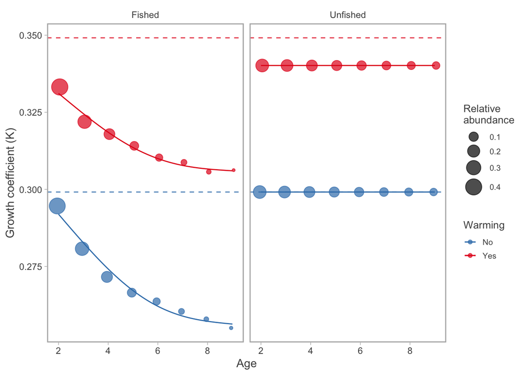

```r
# Plot!
pop_all <- pop_all |>
  left_join(temp_series, by = "year") |>
  mutate(
    Fishing = ifelse(str_detect(scenario, "^Fished"), "Fished", "Unfished"),
    Warming = ifelse(str_detect(scenario, "_Warming$"), "Yes", "No")
  )

# Sample points weighted by N
k_last_year <- pop_all |>
  filter(age <= 9, age > 1, year == max(year)) |>
  summarise(
    mean = sum(K * N) / sum(N),
    totalN = sum(N),
    .by = c(Fishing, Warming, age)
  ) |>
  mutate(rel_abund = totalN / sum(totalN),
         .by = c(Fishing, Warming))

# Compute expected K at last year given true effect of warming
expected_K <- growth_params |>
  select(platoon, K) |>
  summarise(K_base = mean(K)) |>
  mutate(K_end_warming = K_base + deltaK_perC * 2)  # 2=total_warming in C

vlines_K <- tibble(
  K_line = c(expected_K$K_base, expected_K$K_end_warming),
  Warming = c("No", "Yes")
)

ggplot(k_last_year, aes(age, mean, color = Warming, size = rel_abund)) +
  geom_hline(data = vlines_K, aes(yintercept = K_line, color = Warming),
             linetype = 2, alpha = 0.8) +
  geom_point(position = position_dodge(width = 0.2), alpha = 0.7) +
  geom_smooth(method = "gam", formula = y ~ s(x, k = 3), se = FALSE,
              inherit.aes = FALSE, linewidth = 0.5,
              aes(age, mean, color = Warming)) +
  scale_color_brewer(palette = "Set1", direction = -1) +
  scale_size_continuous(range = c(1, 7), name = "Relative\nabundance") +
  labs(x = "Age", y = "Growth coefficient (K)", color = "Warming") +
  facet_wrap(~Fishing)
```

```r
ggsave(paste0(home, "/figures/bias_age.pdf"), width = 17, height = 11, units = "cm")
```

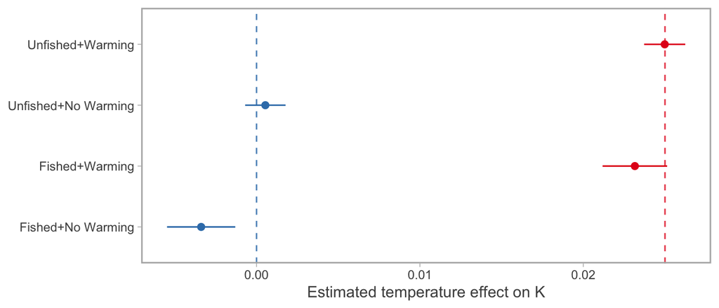

```r
# How well do we estimate the effect of temp on K?
slopes <- pop_all |>
  filter(age <= 9, age > 1) |>
  group_by(Fishing, Warming, age) |>
  slice_sample(n = 5000, weight_by = N, replace = TRUE) |>
  ungroup() |>
  summarise(mean = mean(K), ymin = quantile(K, 0.25), ymax = quantile(K, 0.75),
            .by = c(Fishing, Warming, age, temp, year)) |>
  mutate(scenario = paste(Fishing, Warming, sep = "_")) %>%
  split(.$scenario) %>%
  map_dfr(~ {
    fit <- lm(mean ~ temp, data = .)
    tidy(fit) %>% filter(term == "temp")
  }, .id = "scenario") |>
  separate(scenario, into = c("Fishing", "Warming"), sep = "_", remove = FALSE) |>
  mutate(
    Warming = if_else(Warming == "Yes", "Warming", "No Warming"),
    scen = paste(Fishing, "+", Warming, sep = "")
  )

vlines <- tibble(
  x = c(0, deltaK_perC),
  Warming = c("No Warming", "Warming")
)

ggplot(slopes, aes(estimate, scen, color = Warming)) +
  geom_vline(data = vlines, aes(xintercept = x, color = Warming),
             linetype = 2, alpha = 0.8) +
  geom_point(size = 2) +
  geom_errorbar(aes(xmin = estimate - std.error*1.96,
                    xmax = estimate + std.error*1.96), width = 0) +
  scale_color_brewer(palette = "Set1", direction = -1) +
  guides(color = "none") +
  labs(x = "Estimated temperature effect on K") +
  theme(axis.title.y = element_blank())
```

```r
ggsave(paste0(home, "/figures/bias.pdf"), width = 10, height = 7, units = "cm")
```

### Conclusion

- In the un-fished scenarios, no warming scenario, we can correctly retrieve the true K (this is really just a sanity test). In the unfished + warming scenario, we sort of can, but there’s a small bias (that disappears. when I reduce temperature noise).
- As for the *temperature effect on K*, we correctly retrieve the slope in the unfished scenarios. When we have fishing + no warming, we erroneously estimate a negative temperature effect on K (that’s the Rosa Lee effect), and in the fishing + warming scenario, we underestimate the true temperature effect on K.

### To do

Some ideas for extensions are:

- More simulations (more true slopes, more rates of warming)
- Other life histories? I had cod in mind here (slow growing, long lived [with some modifications]), but we could consider a flatfish (fast growth, long life), and a forage fish (fast growth, short life), following `ss3sim` categories.